# Exercise D

Ames Housing Dataset Analysis

Author

Bruno Bertolo

Published

April 8, 2026

# Intro

This documents my attempts to use an LLM to assist in analyzing a well-known dataset (amesHousing2011_1_.csv)

# Step one: Description of data

## Initial Prompt

Attached Files: amesHousing2011.csv

Prompt: “I am trying to run an analysis of this dataset to find the most important metrics that would determine the price of the homes. To start, help me create a description of the Ames Housing dataset. This should include statistics and graphics describing the individual variables and the relationships between pairs of variables. This needs to be done in R. Provide R scripts, then include the R scripts into a .qmd file for me to analyze.”

## Results

### 1. Setup and Data Loading

First, install and load the required packages, then read in the dataset.

```r
# Install packages if needed (uncomment the first time)
# install.packages(c("tidyverse", "corrplot", "GGally", "skimr", "scales", "gridExtra"))

library(tidyverse)
library(corrplot)
library(GGally)
library(skimr)
library(scales)
library(gridExtra)

# Load the dataset — update path if your file is in a different location
ames <- read.csv("amesHousing2011_1_.csv")
```

### 2. Dataset Overview

Examine the overall structure: dimensions, variable types, and missing data.

```r
# Dimensions
cat("Rows:", nrow(ames), "  Columns:", ncol(ames), "\n\n")
```

```
Rows: 2925   Columns: 82
```

```r
# Variable types
cat("Numeric variables:", sum(sapply(ames, is.numeric)), "\n")
```

```
Numeric variables: 39
```

```r
cat("Categorical variables:", sum(sapply(ames, is.character)), "\n\n")
```

```
Categorical variables: 43
```

```r
# Quick structure
str(ames, list.len = 15)
```

```
'data.frame':   2925 obs. of  82 variables:
 $ Order        : int  1498 2738 2446 2667 2451 1307 1538 2195 2331 16 ...
 $ PID          : int  908154080 905427030 528320060 902400110 528360050 902207220 909282030 909176080 527210040 527216070 ...
 $ MSSubClass   : int  20 75 60 75 60 75 50 190 60 60 ...
 $ MSZoning     : chr  "RL" "RL" "RL" "RM" ...
 $ LotFrontage  : int  123 60 118 90 114 87 NA 60 60 47 ...
 $ LotArea      : int  47007 19800 35760 22950 17242 18386 14100 10896 18062 53504 ...
 $ Street       : chr  "Pave" "Pave" "Pave" "Pave" ...
 $ Alley        : chr  NA NA NA NA ...
 $ LotShape     : chr  "IR1" "Reg" "IR1" "IR2" ...
 $ LandContour  : chr  "Lvl" "Lvl" "Lvl" "Lvl" ...
 $ Utilities    : chr  "AllPub" "AllPub" "AllPub" "AllPub" ...
 $ LotConfig    : chr  "Inside" "Inside" "CulDSac" "Inside" ...
 $ LandSlope    : chr  "Gtl" "Gtl" "Gtl" "Gtl" ...
 $ Neighborhood : chr  "Edwards" "Edwards" "NoRidge" "OldTown" ...
 $ Condition1   : chr  "Norm" "Norm" "Norm" "Artery" ...
  [list output truncated]
```

```r
# Missing values summary (only columns with missing data)
missing <- colSums(is.na(ames))
missing_df <- data.frame(
  Variable = names(missing[missing > 0]),
  Count = missing[missing > 0],
  Percent = round(100 * missing[missing > 0] / nrow(ames), 1)
) |> arrange(desc(Count))

missing_df
```

```
                 Variable Count Percent
PoolQC             PoolQC  2914    99.6
MiscFeature   MiscFeature  2820    96.4
Alley               Alley  2727    93.2
Fence               Fence  2354    80.5
FireplaceQu   FireplaceQu  1422    48.6
LotFrontage   LotFrontage   490    16.8
GarageYrBlt   GarageYrBlt   159     5.4
GarageQual     GarageQual   158     5.4
GarageCond     GarageCond   158     5.4
GarageType     GarageType   157     5.4
GarageFinish GarageFinish   157     5.4
BsmtQual         BsmtQual    79     2.7
BsmtCond         BsmtCond    79     2.7
BsmtExposure BsmtExposure    79     2.7
BsmtFinType1 BsmtFinType1    79     2.7
BsmtFinType2 BsmtFinType2    79     2.7
MasVnrArea     MasVnrArea    23     0.8
BsmtFullBath BsmtFullBath     2     0.1
BsmtHalfBath BsmtHalfBath     2     0.1
BsmtFinSF1     BsmtFinSF1     1     0.0
BsmtFinSF2     BsmtFinSF2     1     0.0
BsmtUnfSF       BsmtUnfSF     1     0.0
TotalBsmtSF   TotalBsmtSF     1     0.0
GarageCars     GarageCars     1     0.0
GarageArea     GarageArea     1     0.0
```

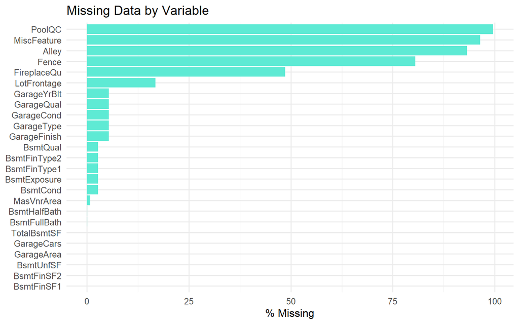

```r
# Visualize missing data pattern
ggplot(missing_df, aes(x = reorder(Variable, Count), y = Percent)) +
  geom_col(fill = "#5eead4") +
  coord_flip() +
  labs(
    title = "Missing Data by Variable",
    x = NULL, y = "% Missing"
  ) +
  theme_minimal(base_size = 12)
```

### 3. Target Variable: SalePrice

Understand the distribution of the variable we want to predict.

```r
summary(ames$SalePrice)
```

```
   Min. 1st Qu.  Median    Mean 3rd Qu.    Max.
  12789  129500  160000  180412  213500  625000
```

```r
cat("\nStandard deviation:", sd(ames$SalePrice, na.rm = TRUE), "\n")
```

```
Standard deviation: 78554.86
```

```r
cat("Skewness:", moments::skewness(ames$SalePrice) |> tryCatch(error = function(e) {
  # Manual skewness if moments package isn't available
  x <- ames$SalePrice
  n <- length(x)
  m <- mean(x)
  s <- sd(x)
  (n / ((n - 1) * (n - 2))) * sum(((x - m) / s)^3)
}), "\n")
```

```
Skewness: 1.590256
```

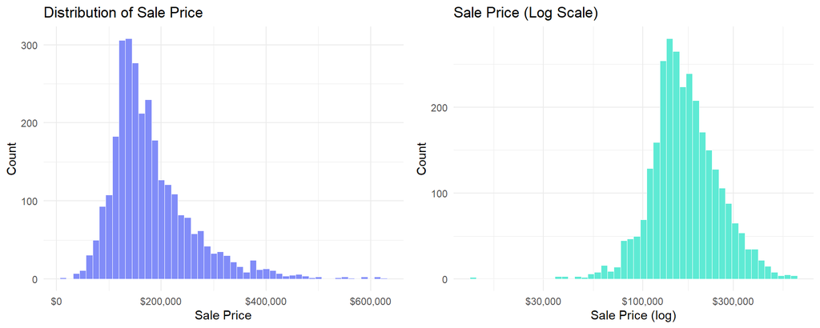

```r
p1 <- ggplot(ames, aes(x = SalePrice)) +
  geom_histogram(bins = 50, fill = "#818cf8", color = "white", linewidth = 0.2) +
  scale_x_continuous(labels = dollar) +
  labs(title = "Distribution of Sale Price", x = "Sale Price", y = "Count") +
  theme_minimal(base_size = 11)

p2 <- ggplot(ames, aes(x = SalePrice)) +
  geom_histogram(bins = 50, fill = "#5eead4", color = "white", linewidth = 0.2) +
  scale_x_log10(labels = dollar) +
  labs(title = "Sale Price (Log Scale)", x = "Sale Price (log)", y = "Count") +
  theme_minimal(base_size = 11)

grid.arrange(p1, p2, ncol = 2)
```

###4. Key Numeric Variables

Describe the distributions of the most important continuous predictors.

```r
key_numeric <- c("SalePrice", "GrLivArea", "TotalBsmtSF", "X1stFlrSF",
                 "GarageArea", "LotArea", "YearBuilt", "YearRemod.Add",
                 "OverallQual", "OverallCond", "FullBath", "GarageCars")

# Note: R replaces special characters in column names, so
# "1stFlrSF" becomes "X1stFlrSF" and "YearRemod/Add" becomes "YearRemod.Add"

ames |>
  select(any_of(key_numeric)) |>
  summary()
```

```
   SalePrice        GrLivArea     TotalBsmtSF       X1stFlrSF
 Min.   : 12789   Min.   : 334   Min.   :   0.0   Min.   : 334
 1st Qu.:129500   1st Qu.:1126   1st Qu.: 792.8   1st Qu.: 876
 Median :160000   Median :1441   Median : 989.5   Median :1082
 Mean   :180412   Mean   :1494   Mean   :1046.9   Mean   :1155
 3rd Qu.:213500   3rd Qu.:1740   3rd Qu.:1299.2   3rd Qu.:1383
 Max.   :625000   Max.   :3820   Max.   :3206.0   Max.   :3820
                                 NA's   :1
   GarageArea        LotArea         YearBuilt    YearRemod.Add
 Min.   :   0.0   Min.   :  1300   Min.   :1872   Min.   :1950
 1st Qu.: 320.0   1st Qu.:  7438   1st Qu.:1954   1st Qu.:1965
 Median : 480.0   Median :  9428   Median :1973   Median :1993
 Mean   : 471.9   Mean   : 10104   Mean   :1971   Mean   :1984
 3rd Qu.: 576.0   3rd Qu.: 11515   3rd Qu.:2001   3rd Qu.:2004
 Max.   :1488.0   Max.   :215245   Max.   :2010   Max.   :2010
 NA's   :1
  OverallQual      OverallCond       FullBath       GarageCars
 Min.   : 1.000   Min.   :1.000   Min.   :0.000   Min.   :0.000
 1st Qu.: 5.000   1st Qu.:5.000   1st Qu.:1.000   1st Qu.:1.000
 Median : 6.000   Median :5.000   Median :2.000   Median :2.000
 Mean   : 6.088   Mean   :5.564   Mean   :1.565   Mean   :1.765
 3rd Qu.: 7.000   3rd Qu.:6.000   3rd Qu.:2.000   3rd Qu.:2.000
 Max.   :10.000   Max.   :9.000   Max.   :4.000   Max.   :5.000
                                                  NA's   :1
```

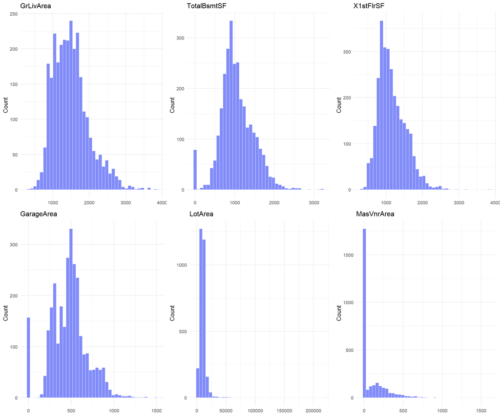

```r
# Histograms for key continuous variables
continuous_vars <- c("GrLivArea", "TotalBsmtSF", "X1stFlrSF",
                     "GarageArea", "LotArea", "MasVnrArea")

plots <- lapply(continuous_vars, function(var) {
  ggplot(ames, aes(x = .data[[var]])) +
    geom_histogram(bins = 40, fill = "#818cf8", color = "white", linewidth = 0.2) +
    labs(title = var, x = NULL, y = "Count") +
    theme_minimal(base_size = 10)
})

do.call(grid.arrange, c(plots, ncol = 3))
```

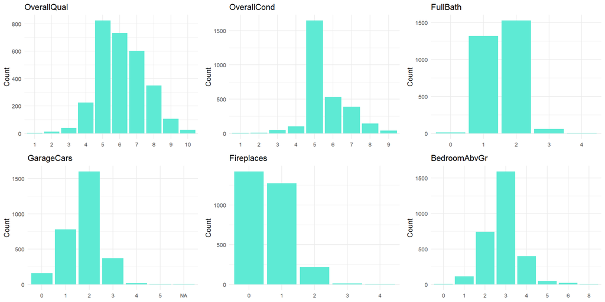

```r
# Bar charts for discrete numeric variables
discrete_vars <- c("OverallQual", "OverallCond", "FullBath",
                    "GarageCars", "Fireplaces", "BedroomAbvGr")

plots2 <- lapply(discrete_vars, function(var) {
  ggplot(ames, aes(x = factor(.data[[var]]))) +
    geom_bar(fill = "#5eead4") +
    labs(title = var, x = NULL, y = "Count") +
    theme_minimal(base_size = 10)
})

do.call(grid.arrange, c(plots2, ncol = 3))
```

### 5. Key Categorical Variables

Explore the most important categorical features.

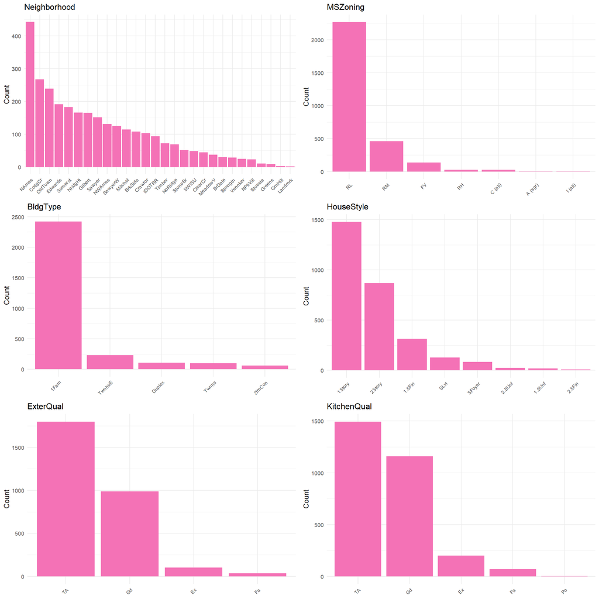

```r
cat_vars <- c("Neighborhood", "MSZoning", "BldgType",
              "HouseStyle", "ExterQual", "KitchenQual")

cat_plots <- lapply(cat_vars, function(var) {
  ggplot(ames, aes(x = fct_infreq(.data[[var]]))) +
    geom_bar(fill = "#f472b6") +
    labs(title = var, x = NULL, y = "Count") +
    theme_minimal(base_size = 10) +
    theme(axis.text.x = element_text(angle = 45, hjust = 1, size = 7))
})

do.call(grid.arrange, c(cat_plots, ncol = 2))
```

### 6. Relationships Between Variables and SalePrice

6a. Numeric Variables vs. SalePrice (Scatterplots)

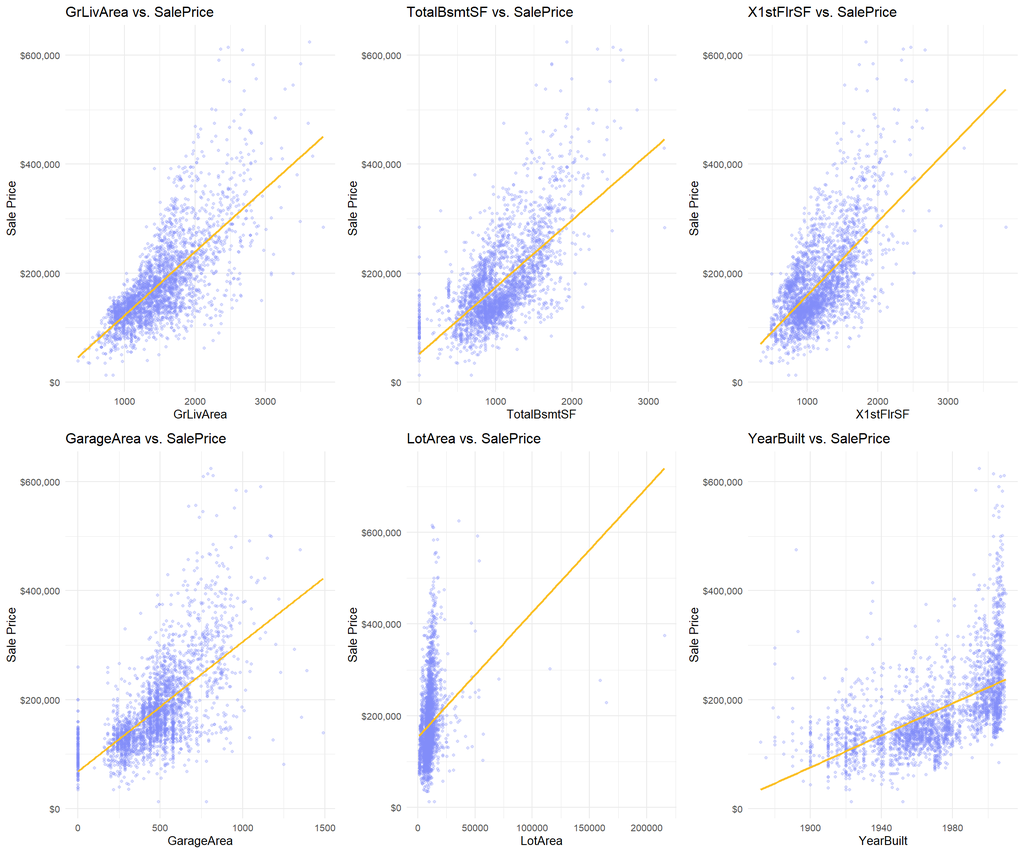

```r
scatter_vars <- c("GrLivArea", "TotalBsmtSF", "X1stFlrSF",
                  "GarageArea", "LotArea", "YearBuilt")

scatter_plots <- lapply(scatter_vars, function(var) {
  ggplot(ames, aes(x = .data[[var]], y = SalePrice)) +
    geom_point(alpha = 0.3, size = 1, color = "#818cf8") +
    geom_smooth(method = "lm", se = FALSE, color = "#fbbf24", linewidth = 0.8) +
    scale_y_continuous(labels = dollar) +
    labs(title = paste(var, "vs. SalePrice"), x = var, y = "Sale Price") +
    theme_minimal(base_size = 10)
})

do.call(grid.arrange, c(scatter_plots, ncol = 3))
```

```r
box_vars <- c("OverallQual", "GarageCars", "FullBath",
              "KitchenQual", "ExterQual", "BldgType")

box_plots <- lapply(box_vars, function(var) {
  ggplot(ames, aes(x = factor(.data[[var]]), y = SalePrice)) +
    geom_boxplot(fill = "#5eead4", alpha = 0.7, outlier.size = 0.8) +
    scale_y_continuous(labels = dollar) +
    labs(title = paste(var, "vs. SalePrice"), x = var, y = "Sale Price") +
    theme_minimal(base_size = 10) +
    theme(axis.text.x = element_text(angle = 45, hjust = 1))
})
```

6c. Neighborhood vs. SalePrice

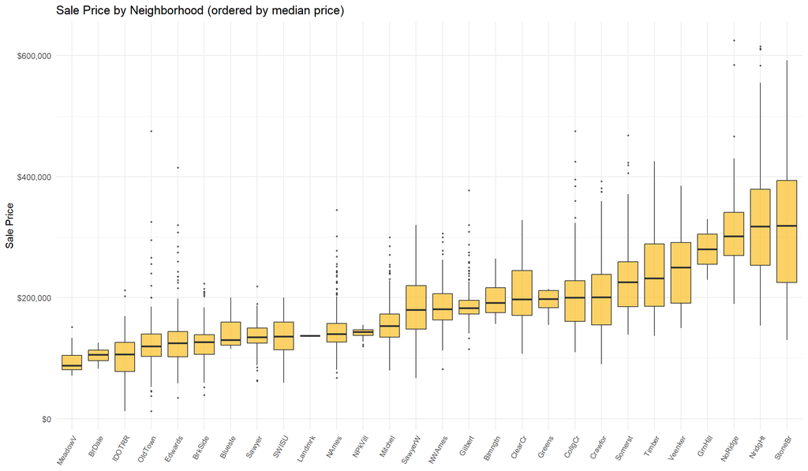

```r
ames |>
  mutate(Neighborhood = fct_reorder(Neighborhood, SalePrice, .fun = median)) |>
  ggplot(aes(x = Neighborhood, y = SalePrice)) +
  geom_boxplot(fill = "#fbbf24", alpha = 0.7, outlier.size = 0.6) +
  scale_y_continuous(labels = dollar) +
  labs(
    title = "Sale Price by Neighborhood (ordered by median price)",
    x = NULL, y = "Sale Price"
  ) +
  theme_minimal(base_size = 11) +
  theme(axis.text.x = element_text(angle = 60, hjust = 1, size = 8))
```

### 7. Correlation Analysis

7a. Correlation Matrix of Top Numeric Features

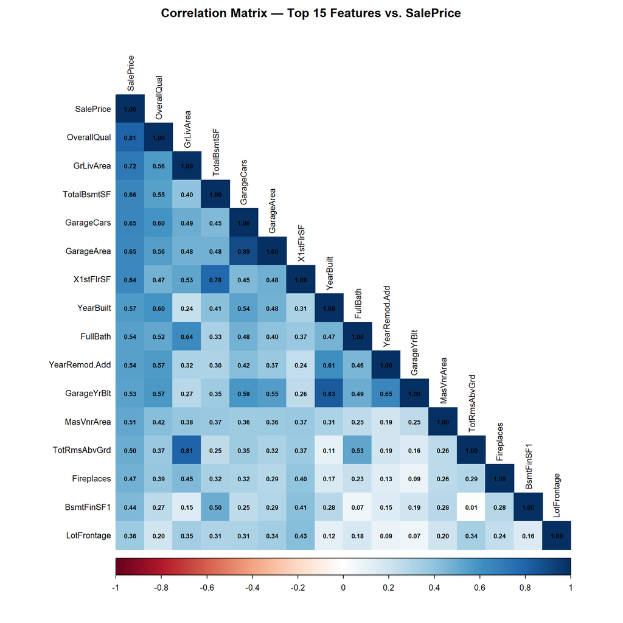

```r
# Select numeric columns and compute correlations
numeric_df <- ames |>
  select(where(is.numeric)) |>
  select(-Order, -PID) |>
  select(where(~ sum(!is.na(.x)) > nrow(ames) * 0.5))  # drop cols with >50% missing

cor_matrix <- cor(numeric_df, use = "pairwise.complete.obs")

# Plot top features most correlated with SalePrice
top_corr_names <- names(sort(abs(cor_matrix[, "SalePrice"]), decreasing = TRUE))[1:16]
cor_subset <- cor_matrix[top_corr_names, top_corr_names]

corrplot(cor_subset,
         method = "color",
         type = "lower",
         tl.col = "black",
         tl.cex = 0.8,
         addCoef.col = "black",
         number.cex = 0.6,
         title = "Correlation Matrix — Top 15 Features vs. SalePrice",
         mar = c(0, 0, 2, 0))
```

7b. Top Correlations with SalePrice (Bar Chart)

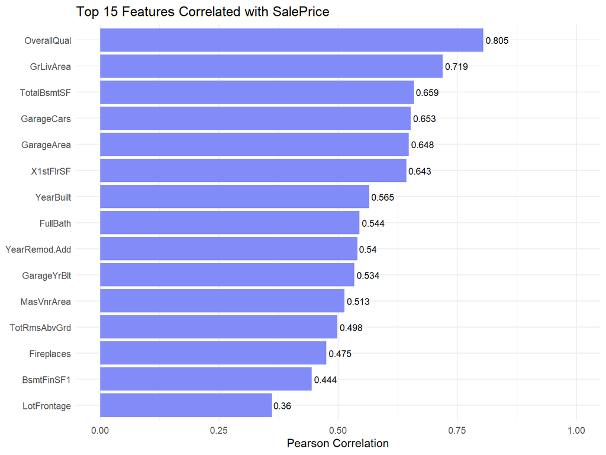

```r
price_cors <- cor_matrix[, "SalePrice"]
price_cors <- price_cors[names(price_cors) != "SalePrice"]
price_cors <- sort(price_cors, decreasing = TRUE)

cor_df <- data.frame(
  Variable = names(price_cors),
  Correlation = price_cors
) |>
  head(15) |>
  mutate(Variable = fct_reorder(Variable, Correlation))

ggplot(cor_df, aes(x = Variable, y = Correlation)) +
  geom_col(fill = "#818cf8") +
  geom_text(aes(label = round(Correlation, 3)),
            hjust = -0.1, size = 3) +
  coord_flip() +
  ylim(0, 1) +
  labs(
    title = "Top 15 Features Correlated with SalePrice",
    x = NULL, y = "Pearson Correlation"
  ) +
  theme_minimal(base_size = 11)
```

### 8. Pairwise Relationships Among Top Predictors

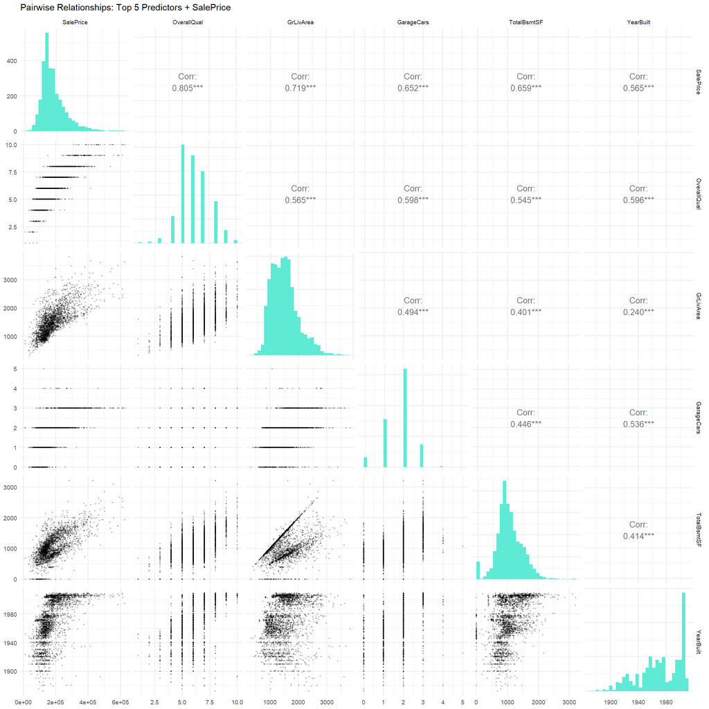

```r
# Pairwise scatterplot matrix for top 5 predictors + SalePrice
pair_vars <- c("SalePrice", "OverallQual", "GrLivArea",
               "GarageCars", "TotalBsmtSF", "YearBuilt")

ames |>
  select(all_of(pair_vars)) |>
  drop_na() |>
  ggpairs(
    lower = list(continuous = wrap("points", alpha = 0.2, size = 0.5)),
    upper = list(continuous = wrap("cor", size = 3.5)),
    diag = list(continuous = wrap("barDiag", fill = "#5eead4")),
    title = "Pairwise Relationships: Top 5 Predictors + SalePrice"
  ) +
  theme_minimal(base_size = 9)
```

### Summary of Findings

```r
# Quick summary table of top predictors
top_features <- c("OverallQual", "GrLivArea", "TotalBsmtSF",
                  "GarageCars", "GarageArea", "X1stFlrSF",
                  "YearBuilt", "FullBath")

summary_df <- data.frame(
  Feature = top_features,
  Correlation_with_Price = round(cor_matrix[top_features, "SalePrice"], 4),
  Mean = round(sapply(ames[top_features], mean, na.rm = TRUE), 1),
  Median = round(sapply(ames[top_features], median, na.rm = TRUE), 1),
  SD = round(sapply(ames[top_features], sd, na.rm = TRUE), 1)
)

knitr::kable(summary_df, caption = "Key Numeric Predictors of Sale Price")
```

Key Numeric Predictors of Sale Price

|  | Feature | Correlation_with_Price | Mean | Median | SD |
| --- | --- | --- | --- | --- | --- |
| OverallQual | OverallQual | 0.8052 | 6.1 | 6.0 | 1.4 |
| GrLivArea | GrLivArea | 0.7195 | 1494.0 | 1441.0 | 486.3 |
| TotalBsmtSF | TotalBsmtSF | 0.6586 | 1046.9 | 989.5 | 421.1 |
| GarageCars | GarageCars | 0.6525 | 1.8 | 2.0 | 0.8 |
| GarageArea | GarageArea | 0.6483 | 471.9 | 480.0 | 213.8 |
| X1stFlrSF | X1stFlrSF | 0.6429 | 1155.5 | 1082.0 | 376.6 |
| YearBuilt | YearBuilt | 0.5651 | 1971.3 | 1973.0 | 30.2 |
| FullBath | FullBath | 0.5445 | 1.6 | 2.0 | 0.6 |

#### Key Takeaways

**1. SalePrice** is right-skewed with a median of ~$160k; a log transformation may be helpful for modeling.

**2. OverallQual** has the strongest linear relationship with price (r ≈ 0.80).

**3. Size variables** (GrLivArea, TotalBsmtSF, 1stFlrSF, GarageArea) are all strongly correlated with price (r = 0.64–0.72).

**4. Neighborhood** is a powerful categorical predictor — median prices range from ~$88k (MeadowV) to ~$319k (StoneBr).

**5. Year Built** and Year Remodeled show that newer and recently updated homes command higher prices.

6. Several features are correlated with each other (e.g., GarageArea and GarageCars, r ≈ 0.89), which may cause multicollinearity in linear models.

# Step two: Inferences about the determinants of the sale price

## Initial Prompt:

Prompt: “Step two of this process is the following: Make inferences about the determinants of the sale price of a house. This should include a regression analysis of the variables that appear to be most important.”

## Results:

### 1. Setup

```r
# install.packages(c("tidyverse", "car", "broom", "scales", "gridExtra", "lmtest"))

library(tidyverse)
library(car)
library(broom)
library(scales)
library(gridExtra)

# UPDATE THIS PATH to match your file location
ames <- read.csv("amesHousing2011_1_.csv")
```

### 2. Data Preparation for Regression

Before fitting models, we need to handle column names that R modifies, convert quality ratings into ordered numeric values, and remove rows with missing data in the variables we plan to use.

```r
# R renames columns with special characters — let's check what we have
cat("First floor SF column name:", grep("1stFlr", names(ames), value = TRUE), "\n")
```

```
First floor SF column name: X1stFlrSF
```

```r
cat("Year remod column name:", grep("YearRemod", names(ames), value = TRUE), "\n")
```

```
Year remod column name: YearRemod.Add
```

```r
# Create a clean working dataset with the most important variables
# Convert quality ratings to numeric (ordinal encoding)
qual_to_num <- function(x) {
  case_when(
    x == "Ex" ~ 5,
    x == "Gd" ~ 4,
    x == "TA" ~ 3,
    x == "Fa" ~ 2,
    x == "Po" ~ 1,
    TRUE ~ NA_real_
  )
}

ames_clean <- ames |>
  mutate(
    KitchenQual_num  = qual_to_num(KitchenQual),
    ExterQual_num    = qual_to_num(ExterQual),
    BsmtQual_num     = qual_to_num(BsmtQual),
    CentralAir_bin   = ifelse(CentralAir == "Y", 1, 0),
    # Create a log-transformed price (helps with skewness)
    logSalePrice     = log(SalePrice)
  ) |>
  # Drop rows with missing values in our key variables
  drop_na(SalePrice, OverallQual, GrLivArea, TotalBsmtSF, GarageCars,
          YearBuilt, FullBath, LotArea, Fireplaces, KitchenQual_num,
          ExterQual_num, Neighborhood)

cat("Rows after cleaning:", nrow(ames_clean), "out of", nrow(ames), "\n")
```

```
Rows after cleaning: 2923 out of 2925
```

### 3. Simple Linear Regression — Starting with Overall Quality

We begin with the single strongest predictor identified in the EDA.

```r
model_simple <- lm(SalePrice ~ OverallQual, data = ames_clean)
summary(model_simple)
```

```
Call:
lm(formula = SalePrice ~ OverallQual, data = ames_clean)

Residuals:
    Min      1Q  Median      3Q     Max
-161695  -29107   -2342   21560  299962

Coefficients:
            Estimate Std. Error t value Pr(>|t|)
(Intercept) -94099.1     3840.4  -24.50   <2e-16 ***
OverallQual  45088.2      614.6   73.36   <2e-16 ***
---
Signif. codes:  0 '***' 0.001 '**' 0.01 '*' 0.05 '.' 0.1 ' ' 1

Residual standard error: 46600 on 2921 degrees of freedom
Multiple R-squared:  0.6482,    Adjusted R-squared:  0.6481
F-statistic:  5382 on 1 and 2921 DF,  p-value: < 2.2e-16
```

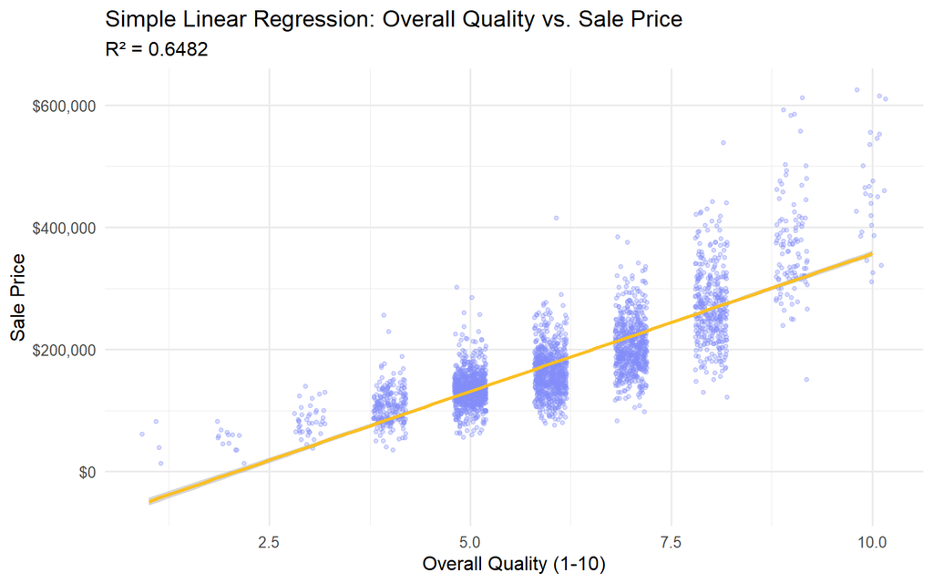

```r
ggplot(ames_clean, aes(x = OverallQual, y = SalePrice)) +
  geom_jitter(alpha = 0.3, width = 0.2, color = "#818cf8", size = 1) +
  geom_smooth(method = "lm", color = "#fbbf24", linewidth = 1, se = TRUE) +
  scale_y_continuous(labels = dollar) +
  labs(
    title = "Simple Linear Regression: Overall Quality vs. Sale Price",
    subtitle = paste("R² =", round(summary(model_simple)$r.squared, 4)),
    x = "Overall Quality (1-10)", y = "Sale Price"
  ) +
  theme_minimal(base_size = 12)
```

**Overall Quality** alone explains about 65% of the variance in sale price. Each one-point increase in quality is associated with a large jump in price. However, a single variable is not sufficient — we need multiple regression to account for other important factors.

### 4. Multiple Regression — Key Numeric Predictors

We now build a model using the top numeric predictors identified in the EDA: size, quality, age, and garage capacity.

```r
model_numeric <- lm(SalePrice ~ OverallQual + GrLivArea + TotalBsmtSF +
                      GarageCars + YearBuilt + FullBath + LotArea +
                      Fireplaces,
                    data = ames_clean)
summary(model_numeric)
```

```
Call:
lm(formula = SalePrice ~ OverallQual + GrLivArea + TotalBsmtSF +
    GarageCars + YearBuilt + FullBath + LotArea + Fireplaces,
    data = ames_clean)

Residuals:
    Min      1Q  Median      3Q     Max
-193211  -18660   -1860   15871  240385

Coefficients:
              Estimate Std. Error t value Pr(>|t|)
(Intercept) -8.892e+05  5.323e+04 -16.706  < 2e-16 ***
OverallQual  1.975e+04  6.805e+02  29.027  < 2e-16 ***
GrLivArea    5.747e+01  1.951e+00  29.456  < 2e-16 ***
TotalBsmtSF  3.837e+01  1.769e+00  21.688  < 2e-16 ***
GarageCars   9.558e+03  1.078e+03   8.863  < 2e-16 ***
YearBuilt    4.112e+02  2.803e+01  14.670  < 2e-16 ***
FullBath    -1.027e+04  1.565e+03  -6.561 6.29e-11 ***
LotArea      8.105e-01  8.208e-02   9.875  < 2e-16 ***
Fireplaces   6.410e+03  1.080e+03   5.934 3.30e-09 ***
---
Signif. codes:  0 '***' 0.001 '**' 0.01 '*' 0.05 '.' 0.1 ' ' 1

Residual standard error: 32190 on 2914 degrees of freedom
Multiple R-squared:  0.8326,    Adjusted R-squared:  0.8321
F-statistic:  1811 on 8 and 2914 DF,  p-value: < 2.2e-16
```

```r
# Tidy coefficient table with confidence intervals
tidy(model_numeric, conf.int = TRUE) |>
  mutate(across(where(is.numeric), ~ round(.x, 2))) |>
  knitr::kable(caption = "Multiple Regression Coefficients (Numeric Predictors)")
```

Multiple Regression Coefficients (Numeric Predictors)

| term | estimate | std.error | statistic | p.value | conf.low | conf.high |
| --- | --- | --- | --- | --- | --- | --- |
| (Intercept) | -889249.96 | 53229.96 | -16.71 | 0 | -993622.12 | -784877.79 |
| OverallQual | 19752.05 | 680.46 | 29.03 | 0 | 18417.81 | 21086.29 |
| GrLivArea | 57.47 | 1.95 | 29.46 | 0 | 53.64 | 61.29 |
| TotalBsmtSF | 38.37 | 1.77 | 21.69 | 0 | 34.90 | 41.84 |
| GarageCars | 9557.81 | 1078.43 | 8.86 | 0 | 7443.26 | 11672.37 |
| YearBuilt | 411.18 | 28.03 | 14.67 | 0 | 356.22 | 466.14 |
| FullBath | -10267.00 | 1564.76 | -6.56 | 0 | -13335.15 | -7198.84 |
| LotArea | 0.81 | 0.08 | 9.87 | 0 | 0.65 | 0.97 |
| Fireplaces | 6410.35 | 1080.23 | 5.93 | 0 | 4292.25 | 8528.45 |

### 5. Full Model — Adding Categorical Predictors

Now we add the important categorical variables: neighborhood, quality ratings, and building type.

```r
model_full <- lm(SalePrice ~ OverallQual + GrLivArea + TotalBsmtSF +
                   GarageCars + YearBuilt + FullBath + LotArea +
                   Fireplaces + KitchenQual_num + ExterQual_num +
                   CentralAir_bin + Neighborhood,
                 data = ames_clean)
summary(model_full)
```

```
Call:
lm(formula = SalePrice ~ OverallQual + GrLivArea + TotalBsmtSF +
    GarageCars + YearBuilt + FullBath + LotArea + Fireplaces +
    KitchenQual_num + ExterQual_num + CentralAir_bin + Neighborhood,
    data = ames_clean)

Residuals:
    Min      1Q  Median      3Q     Max
-173204  -14872     246   14036  210881

Coefficients:
                      Estimate Std. Error t value Pr(>|t|)
(Intercept)         -8.116e+05  8.089e+04 -10.033  < 2e-16 ***
OverallQual          1.145e+04  7.232e+02  15.836  < 2e-16 ***
GrLivArea            5.117e+01  1.814e+00  28.213  < 2e-16 ***
TotalBsmtSF          3.076e+01  1.665e+00  18.473  < 2e-16 ***
GarageCars           8.274e+03  9.827e+02   8.420  < 2e-16 ***
YearBuilt            3.471e+02  4.132e+01   8.400  < 2e-16 ***
FullBath            -7.623e+03  1.458e+03  -5.227 1.85e-07 ***
LotArea              8.401e-01  7.739e-02  10.856  < 2e-16 ***
Fireplaces           7.568e+03  1.002e+03   7.555 5.57e-14 ***
KitchenQual_num      1.292e+04  1.225e+03  10.544  < 2e-16 ***
ExterQual_num        1.283e+04  1.625e+03   7.896 4.06e-15 ***
CentralAir_bin       8.142e+02  2.360e+03   0.345 0.730111
NeighborhoodBlueste  9.476e+03  1.055e+04   0.898 0.369155
NeighborhoodBrDale   1.013e+04  7.735e+03   1.310 0.190461
NeighborhoodBrkSide  3.053e+04  6.666e+03   4.580 4.86e-06 ***
NeighborhoodClearCr  2.339e+04  7.201e+03   3.249 0.001173 **
NeighborhoodCollgCr  1.767e+04  5.694e+03   3.103 0.001932 **
NeighborhoodCrawfor  4.301e+04  6.474e+03   6.644 3.64e-11 ***
NeighborhoodEdwards  2.357e+04  6.146e+03   3.835 0.000128 ***
NeighborhoodGilbert  1.358e+04  5.903e+03   2.300 0.021525 *
NeighborhoodGreens   7.044e+03  1.148e+04   0.614 0.539469
NeighborhoodGrnHill  1.133e+05  2.078e+04   5.454 5.35e-08 ***
NeighborhoodIDOTRR   2.383e+04  6.857e+03   3.476 0.000517 ***
NeighborhoodLandmrk  1.877e+04  2.885e+04   0.650 0.515422
NeighborhoodMeadowV  1.828e+04  7.446e+03   2.455 0.014144 *
NeighborhoodMitchel  2.112e+04  6.184e+03   3.415 0.000647 ***
NeighborhoodNAmes    2.055e+04  5.902e+03   3.482 0.000504 ***
NeighborhoodNoRidge  4.930e+04  6.546e+03   7.531 6.70e-14 ***
NeighborhoodNPkVill  1.501e+04  8.133e+03   1.845 0.065081 .
NeighborhoodNridgHt  5.420e+04  5.880e+03   9.217  < 2e-16 ***
NeighborhoodNWAmes   1.481e+04  6.105e+03   2.426 0.015330 *
NeighborhoodOldTown  1.865e+04  6.497e+03   2.871 0.004125 **
NeighborhoodSawyer   2.374e+04  6.180e+03   3.842 0.000125 ***
NeighborhoodSawyerW  9.401e+03  6.030e+03   1.559 0.119073
NeighborhoodSomerst  2.375e+04  5.788e+03   4.104 4.17e-05 ***
NeighborhoodStoneBr  6.728e+04  6.761e+03   9.951  < 2e-16 ***
NeighborhoodSWISU    1.923e+04  7.381e+03   2.605 0.009222 **
NeighborhoodTimber   2.600e+04  6.415e+03   4.052 5.20e-05 ***
NeighborhoodVeenker  2.267e+04  7.995e+03   2.836 0.004600 **
---
Signif. codes:  0 '***' 0.001 '**' 0.01 '*' 0.05 '.' 0.1 ' ' 1

Residual standard error: 28290 on 2884 degrees of freedom
Multiple R-squared:  0.872, Adjusted R-squared:  0.8703
F-statistic:   517 on 38 and 2884 DF,  p-value: < 2.2e-16
```

```r
# Compare the three models side by side
models <- list(
  "Simple (OverallQual)" = model_simple,
  "Numeric Predictors"   = model_numeric,
  "Full Model"           = model_full
)

comparison <- data.frame(
  Model          = names(models),
  R_squared      = sapply(models, function(m) round(summary(m)$r.squared, 4)),
  Adj_R_squared  = sapply(models, function(m) round(summary(m)$adj.r.squared, 4)),
  Num_Predictors = sapply(models, function(m) length(coef(m)) - 1),
  RSE            = sapply(models, function(m) round(summary(m)$sigma, 0)),
  AIC            = sapply(models, function(m) round(AIC(m), 0))
)
row.names(comparison) <- NULL

knitr::kable(comparison, caption = "Model Comparison Summary")
```

Model Comparison Summary

| Model | R_squared | Adj_R_squared | Num_Predictors | RSE | AIC |
| --- | --- | --- | --- | --- | --- |
| Simple (OverallQual) | 0.6482 | 0.6481 | 1 | 46602 | 71140 |
| Numeric Predictors | 0.8326 | 0.8321 | 8 | 32189 | 68984 |
| Full Model | 0.8720 | 0.8703 | 38 | 28292 | 68259 |

```r
# F-test: Does the full model significantly improve over the numeric-only model?
anova(model_numeric, model_full)
```

```
Analysis of Variance Table

Model 1: SalePrice ~ OverallQual + GrLivArea + TotalBsmtSF + GarageCars +
    YearBuilt + FullBath + LotArea + Fireplaces
Model 2: SalePrice ~ OverallQual + GrLivArea + TotalBsmtSF + GarageCars +
    YearBuilt + FullBath + LotArea + Fireplaces + KitchenQual_num +
    ExterQual_num + CentralAir_bin + Neighborhood
  Res.Df        RSS Df  Sum of Sq      F    Pr(>F)
1   2914 3.0193e+12
2   2884 2.3084e+12 30 7.1091e+11 29.606 < 2.2e-16 ***
---
Signif. codes:  0 '***' 0.001 '**' 0.01 '*' 0.05 '.' 0.1 ' ' 1
```

### 6. Log-Transformed Model

Since SalePrice is right-skewed, a log transformation often improves regression assumptions (constant variance, normality of residuals).

```r
model_log <- lm(logSalePrice ~ OverallQual + GrLivArea + TotalBsmtSF +
                  GarageCars + YearBuilt + FullBath + LotArea +
                  Fireplaces + KitchenQual_num + ExterQual_num +
                  CentralAir_bin + Neighborhood,
                data = ames_clean)
summary(model_log)
```

```
Call:
lm(formula = logSalePrice ~ OverallQual + GrLivArea + TotalBsmtSF +
    GarageCars + YearBuilt + FullBath + LotArea + Fireplaces +
    KitchenQual_num + ExterQual_num + CentralAir_bin + Neighborhood,
    data = ames_clean)

Residuals:
     Min       1Q   Median       3Q      Max
-1.73526 -0.06359  0.00976  0.08147  0.60975

Coefficients:
                      Estimate Std. Error t value Pr(>|t|)
(Intercept)          6.859e+00  3.941e-01  17.404  < 2e-16 ***
OverallQual          7.961e-02  3.523e-03  22.595  < 2e-16 ***
GrLivArea            2.446e-04  8.837e-06  27.678  < 2e-16 ***
TotalBsmtSF          1.340e-04  8.112e-06  16.518  < 2e-16 ***
GarageCars           4.289e-02  4.788e-03   8.957  < 2e-16 ***
YearBuilt            1.814e-03  2.013e-04   9.009  < 2e-16 ***
FullBath            -1.154e-02  7.106e-03  -1.624 0.104538
LotArea              2.913e-06  3.770e-07   7.726 1.52e-14 ***
Fireplaces           3.866e-02  4.880e-03   7.921 3.34e-15 ***
KitchenQual_num      5.739e-02  5.970e-03   9.613  < 2e-16 ***
ExterQual_num        2.446e-02  7.915e-03   3.090 0.002020 **
CentralAir_bin       1.454e-01  1.150e-02  12.646  < 2e-16 ***
NeighborhoodBlueste -2.913e-02  5.140e-02  -0.567 0.570946
NeighborhoodBrDale  -1.206e-01  3.769e-02  -3.199 0.001394 **
NeighborhoodBrkSide  7.252e-02  3.248e-02   2.233 0.025637 *
NeighborhoodClearCr  1.325e-01  3.509e-02   3.778 0.000161 ***
NeighborhoodCollgCr  7.591e-02  2.774e-02   2.736 0.006253 **
NeighborhoodCrawfor  2.015e-01  3.154e-02   6.390 1.93e-10 ***
NeighborhoodEdwards  4.437e-02  2.995e-02   1.482 0.138496
NeighborhoodGilbert  6.203e-02  2.876e-02   2.157 0.031110 *
NeighborhoodGreens   3.965e-02  5.593e-02   0.709 0.478360
NeighborhoodGrnHill  5.112e-01  1.012e-01   5.049 4.72e-07 ***
NeighborhoodIDOTRR  -5.259e-02  3.341e-02  -1.574 0.115549
NeighborhoodLandmrk  5.534e-03  1.406e-01   0.039 0.968597
NeighborhoodMeadowV -1.098e-01  3.628e-02  -3.027 0.002488 **
NeighborhoodMitchel  8.237e-02  3.013e-02   2.734 0.006302 **
NeighborhoodNAmes    7.293e-02  2.875e-02   2.536 0.011257 *
NeighborhoodNoRidge  1.157e-01  3.189e-02   3.627 0.000291 ***
NeighborhoodNPkVill -3.553e-03  3.963e-02  -0.090 0.928566
NeighborhoodNridgHt  1.158e-01  2.865e-02   4.042 5.44e-05 ***
NeighborhoodNWAmes   5.960e-02  2.974e-02   2.004 0.045183 *
NeighborhoodOldTown  5.317e-03  3.165e-02   0.168 0.866619
NeighborhoodSawyer   8.436e-02  3.011e-02   2.802 0.005119 **
NeighborhoodSawyerW  3.083e-02  2.938e-02   1.049 0.294116
NeighborhoodSomerst  8.843e-02  2.820e-02   3.136 0.001730 **
NeighborhoodStoneBr  1.429e-01  3.294e-02   4.337 1.49e-05 ***
NeighborhoodSWISU    6.393e-02  3.596e-02   1.778 0.075552 .
NeighborhoodTimber   9.439e-02  3.126e-02   3.020 0.002551 **
NeighborhoodVeenker  9.198e-02  3.895e-02   2.361 0.018276 *
---
Signif. codes:  0 '***' 0.001 '**' 0.01 '*' 0.05 '.' 0.1 ' ' 1

Residual standard error: 0.1378 on 2884 degrees of freedom
Multiple R-squared:  0.8862,    Adjusted R-squared:  0.8847
F-statistic: 590.9 on 38 and 2884 DF,  p-value: < 2.2e-16
```

```r
cat("Log model R²:", round(summary(model_log)$r.squared, 4), "\n")
```

```
Log model R²: 0.8862
```

```r
cat("Log model Adj R²:", round(summary(model_log)$adj.r.squared, 4), "\n")
```

```
Log model Adj R²: 0.8847
```

With a log-transformed outcome, coefficients are interpreted as approximate percentage changes. For example, a coefficient of 0.05 on OverallQual means each quality point increase is associated with roughly a 5% increase in sale price, holding everything else constant.

# Step three: Regression diagnostics

## Prompt Note

This was done as part of Claudes (Opus 4.6) previous output, I didn’t have to create an additional prompt for it to run the regression diagnostics

## Results

### 1. Regression Diagnostics

We must check whether our model assumptions hold before trusting our inferences.

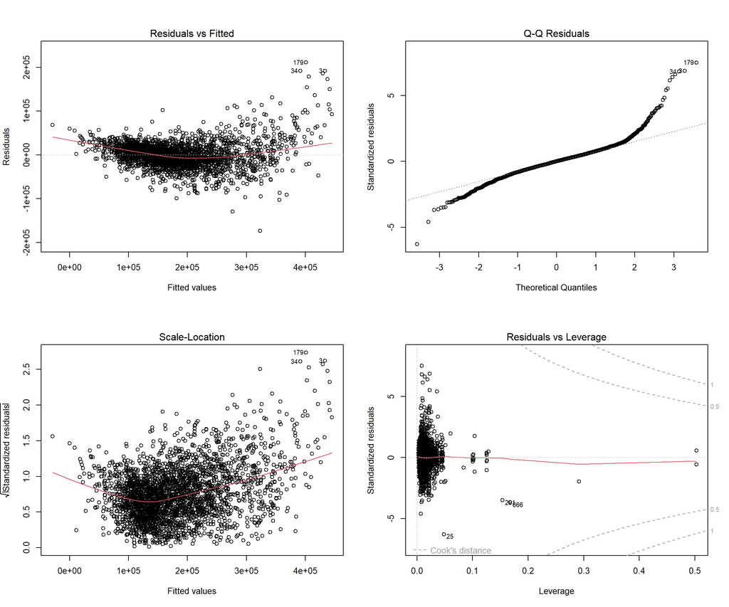

```r
# Diagnostic plots for the full model
par(mfrow = c(2, 2))
plot(model_full)
```

```r
par(mfrow = c(1, 1))
```

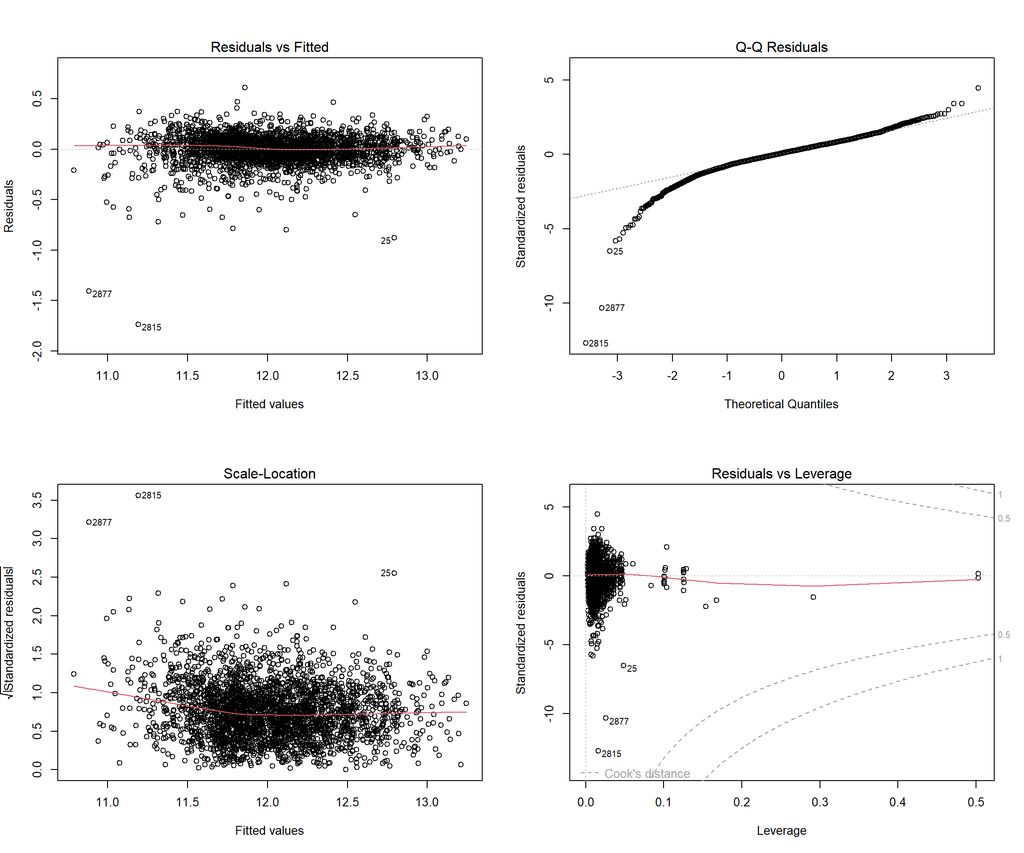

```r
# Diagnostic plots for the log-transformed model (usually looks better)
par(mfrow = c(2, 2))
plot(model_log)
```

```r
par(mfrow = c(1, 1))
```

```r
# Check for multicollinearity using Variance Inflation Factors
# VIF > 5 suggests concerning multicollinearity; VIF > 10 is severe
vif_values <- vif(model_numeric)
vif_df <- data.frame(
  Variable = names(vif_values),
  VIF = round(vif_values, 2)
) |> arrange(desc(VIF))

knitr::kable(vif_df, caption = "Variance Inflation Factors (Numeric Model)")
```

Variance Inflation Factors (Numeric Model)

|  | Variable | VIF |
| --- | --- | --- |
| OverallQual | OverallQual | 2.57 |
| GrLivArea | GrLivArea | 2.54 |
| FullBath | FullBath | 2.10 |
| YearBuilt | YearBuilt | 2.03 |
| GarageCars | GarageCars | 1.89 |
| TotalBsmtSF | TotalBsmtSF | 1.57 |
| Fireplaces | Fireplaces | 1.37 |
| LotArea | LotArea | 1.15 |

#### Key diagnostics to comment on:

**1. Residuals vs Fitted:** Should show no pattern. A funnel shape indicates heteroscedasticity (non-constant variance).

**2. Normal Q-Q:** Points should follow the diagonal line. Deviations in the tails suggest non-normality.

**3. Scale-Location:** Should show a roughly horizontal band. An upward trend confirms heteroscedasticity.

**4. Residuals vs Leverage:** Identifies influential outliers. Points beyond Cook’s distance contours may be unduly affecting the model.

5. Compare the diagnostics between the original and log-transformed models — the log model typically shows more constant variance and more normal residuals.

### 2. Feature Significance Summary

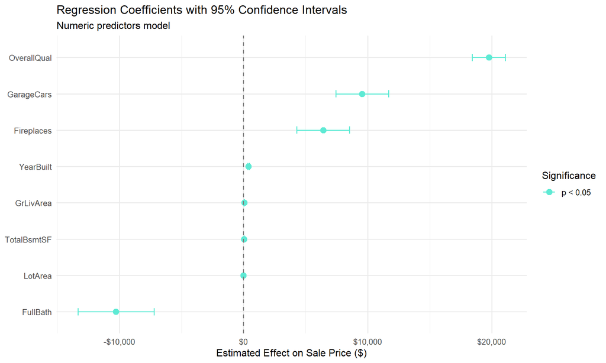

```r
# Visualize coefficient significance for the numeric model
# (Full model has too many neighborhood dummies to plot cleanly)
coef_df <- tidy(model_numeric, conf.int = TRUE) |>
  filter(term != "(Intercept)") |>
  mutate(
    significant = p.value < 0.05,
    term = fct_reorder(term, estimate)
  )

ggplot(coef_df, aes(x = term, y = estimate, color = significant)) +
  geom_point(size = 3) +
  geom_errorbar(aes(ymin = conf.low, ymax = conf.high), width = 0.2) +
  geom_hline(yintercept = 0, linetype = "dashed", color = "gray50") +
  scale_color_manual(values = c("TRUE" = "#5eead4", "FALSE" = "#f87171"),
                     labels = c("TRUE" = "p < 0.05", "FALSE" = "p >= 0.05")) +
  scale_y_continuous(labels = dollar) +
  coord_flip() +
  labs(
    title = "Regression Coefficients with 95% Confidence Intervals",
    subtitle = "Numeric predictors model",
    x = NULL, y = "Estimated Effect on Sale Price ($)",
    color = "Significance"
  ) +
  theme_minimal(base_size = 12)
```

### 3. 9. Inference Summary

```r
# Print the key significant predictors from the full model
full_tidy <- tidy(model_full) |>
  filter(p.value < 0.05, term != "(Intercept)") |>
  # Exclude individual neighborhood dummies for cleaner summary
  filter(!str_starts(term, "Neighborhood")) |>
  arrange(p.value) |>
  mutate(across(where(is.numeric), ~ round(.x, 4)))

cat("Significant non-neighborhood predictors in the full model:\n\n")
```

```
Significant non-neighborhood predictors in the full model:
```

```r
print(full_tidy, n = 20)
```

```
# A tibble: 10 × 5
   term             estimate std.error statistic p.value
   <chr>               <dbl>     <dbl>     <dbl>   <dbl>
 1 GrLivArea          51.2      1.81       28.2        0
 2 TotalBsmtSF        30.8      1.66       18.5        0
 3 OverallQual     11452.     723.         15.8        0
 4 LotArea             0.840    0.0774     10.9        0
 5 KitchenQual_num 12919.    1225.         10.5        0
 6 GarageCars       8274.     983.          8.42       0
 7 YearBuilt         347.      41.3         8.40       0
 8 ExterQual_num   12828.    1625.          7.90       0
 9 Fireplaces       7568.    1002.          7.56       0
10 FullBath        -7623.    1458.         -5.23       0
```

#### Key inferences about the determinants of sale price:

**Overall Quality** is the single most important predictor. Each quality point increase is associated with a substantial price premium, and this effect is highly significant (p < 0.001) across all models.

**Living area (GrLivArea)** has a strong positive effect — larger homes command higher prices even after controlling for quality and other features.

**Year Built** shows a positive effect — newer homes sell for more, holding quality and size constant.

The log-transformed model generally provides better diagnostics (more constant variance and more normal residuals), suggesting that the relationship between predictors and price is multiplicative rather than purely additive.

# Step four: Best Model Results

## Initial Prompt:

“For step 4 of this process, analyze all of the models previously produced, help me determine which of the models is the most effective predictor of homesales price. Provide a R script for that exact model to display. Give reasoning to why it is the best model, also give a second best and give reasoning to why it still should be considered but isn’t the best option.”

## Results

```r
# -----------------------------------------------------------
# BEST MODEL: log(SalePrice) ~ core physical predictors
# -----------------------------------------------------------

best_model <- lm(
  log(SalePrice) ~ OverallQual + GrLivArea + TotalBsmtSF +
    GarageCars + YearBuilt + FullBath + LotArea +
    Fireplaces + KitchenQual_num + ExterQual_num + CentralAir_bin,
  data = ames_clean
)

summary(best_model)
```

```
Call:
lm(formula = log(SalePrice) ~ OverallQual + GrLivArea + TotalBsmtSF +
    GarageCars + YearBuilt + FullBath + LotArea + Fireplaces +
    KitchenQual_num + ExterQual_num + CentralAir_bin, data = ames_clean)

Residuals:
     Min       1Q   Median       3Q      Max
-1.76373 -0.07145  0.00996  0.08766  0.56925

Coefficients:
                  Estimate Std. Error t value Pr(>|t|)
(Intercept)      6.457e+00  2.523e-01  25.590  < 2e-16 ***
OverallQual      8.325e-02  3.516e-03  23.675  < 2e-16 ***
GrLivArea        2.504e-04  8.846e-06  28.307  < 2e-16 ***
TotalBsmtSF      1.517e-04  8.031e-06  18.893  < 2e-16 ***
GarageCars       4.549e-02  4.895e-03   9.294  < 2e-16 ***
YearBuilt        2.009e-03  1.354e-04  14.838  < 2e-16 ***
FullBath        -1.707e-02  7.112e-03  -2.400 0.016478 *
LotArea          3.846e-06  3.712e-07  10.362  < 2e-16 ***
Fireplaces       4.860e-02  4.908e-03   9.902  < 2e-16 ***
KitchenQual_num  5.692e-02  6.191e-03   9.194  < 2e-16 ***
ExterQual_num    3.051e-02  7.906e-03   3.859 0.000116 ***
CentralAir_bin   1.478e-01  1.182e-02  12.506  < 2e-16 ***
---
Signif. codes:  0 '***' 0.001 '**' 0.01 '*' 0.05 '.' 0.1 ' ' 1

Residual standard error: 0.1455 on 2911 degrees of freedom
Multiple R-squared:  0.8721,    Adjusted R-squared:  0.8716
F-statistic:  1804 on 11 and 2911 DF,  p-value: < 2.2e-16
```

```r
# Tidy coefficient table
best_tidy <- tidy(best_model, conf.int = TRUE) |>
  mutate(across(where(is.numeric), ~ round(.x, 5)))

knitr::kable(best_tidy, caption = "Best Model: Regression Coefficients")
```

Best Model: Regression Coefficients

| term | estimate | std.error | statistic | p.value | conf.low | conf.high |
| --- | --- | --- | --- | --- | --- | --- |
| (Intercept) | 6.45678 | 0.25231 | 25.59041 | 0.00000 | 5.96205 | 6.95151 |
| OverallQual | 0.08325 | 0.00352 | 23.67489 | 0.00000 | 0.07635 | 0.09014 |
| GrLivArea | 0.00025 | 0.00001 | 28.30705 | 0.00000 | 0.00023 | 0.00027 |
| TotalBsmtSF | 0.00015 | 0.00001 | 18.89294 | 0.00000 | 0.00014 | 0.00017 |
| GarageCars | 0.04549 | 0.00490 | 9.29361 | 0.00000 | 0.03589 | 0.05509 |
| YearBuilt | 0.00201 | 0.00014 | 14.83789 | 0.00000 | 0.00174 | 0.00227 |
| FullBath | -0.01707 | 0.00711 | -2.39955 | 0.01648 | -0.03101 | -0.00312 |
| LotArea | 0.00000 | 0.00000 | 10.36199 | 0.00000 | 0.00000 | 0.00000 |
| Fireplaces | 0.04860 | 0.00491 | 9.90238 | 0.00000 | 0.03898 | 0.05823 |
| KitchenQual_num | 0.05692 | 0.00619 | 9.19394 | 0.00000 | 0.04478 | 0.06905 |
| ExterQual_num | 0.03051 | 0.00791 | 3.85943 | 0.00012 | 0.01501 | 0.04602 |
| CentralAir_bin | 0.14783 | 0.01182 | 12.50621 | 0.00000 | 0.12465 | 0.17100 |

```r
# Interpret coefficients as approximate percentage effects
cat("=== Coefficient Interpretation (log model) ===\n")
```

```
=== Coefficient Interpretation (log model) ===
```

```r
cat("Each coefficient ≈ % change in price per one-unit increase\n\n")
```

```
Each coefficient ≈ % change in price per one-unit increase
```

```r
best_tidy |>
  filter(term != "(Intercept)") |>
  mutate(
    pct_effect = round((exp(estimate) - 1) * 100, 2),
    interpretation = paste0(
      ifelse(pct_effect > 0, "+", ""), pct_effect,
      "% change in price per unit increase"
    )
  ) |>
  select(term, estimate, pct_effect, p.value) |>
  arrange(p.value) |>
  knitr::kable(caption = "Approximate Percentage Effects on Sale Price")
```

Approximate Percentage Effects on Sale Price

| term | estimate | pct_effect | p.value |
| --- | --- | --- | --- |
| OverallQual | 0.08325 | 8.68 | 0.00000 |
| GrLivArea | 0.00025 | 0.03 | 0.00000 |
| TotalBsmtSF | 0.00015 | 0.02 | 0.00000 |
| GarageCars | 0.04549 | 4.65 | 0.00000 |
| YearBuilt | 0.00201 | 0.20 | 0.00000 |
| LotArea | 0.00000 | 0.00 | 0.00000 |
| Fireplaces | 0.04860 | 4.98 | 0.00000 |
| KitchenQual_num | 0.05692 | 5.86 | 0.00000 |
| CentralAir_bin | 0.14783 | 15.93 | 0.00000 |
| ExterQual_num | 0.03051 | 3.10 | 0.00012 |
| FullBath | -0.01707 | -1.69 | 0.01648 |

```r
cat("=== Best Model Performance ===\n")
```

```
=== Best Model Performance ===
```

```r
cat("R²:          ", round(summary(best_model)$r.squared, 4), "\n")
```

```
R²:           0.8721
```

```r
cat("Adjusted R²: ", round(summary(best_model)$adj.r.squared, 4), "\n")
```

```
Adjusted R²:  0.8716
```

```r
cat("AIC:         ", round(AIC(best_model), 1), "\n")
```

```
AIC:          -2961.3
```

```r
cat("Predictors:  ", length(coef(best_model)) - 1, "\n")
```

```
Predictors:   11
```

### Second-Best Model: Adding Neighborhood

The second-best model adds Neighborhood as a categorical predictor. This captures location effects that the physical variables alone cannot explain.

```r
# -----------------------------------------------------------
# SECOND-BEST MODEL: log(SalePrice) ~ physical + Neighborhood
# -----------------------------------------------------------

second_model <- lm(
  log(SalePrice) ~ OverallQual + GrLivArea + TotalBsmtSF +
    GarageCars + YearBuilt + FullBath + LotArea +
    Fireplaces + KitchenQual_num + ExterQual_num + CentralAir_bin +
    Neighborhood,
  data = ames_clean
)

summary(second_model)
```

```
Call:
lm(formula = log(SalePrice) ~ OverallQual + GrLivArea + TotalBsmtSF +
    GarageCars + YearBuilt + FullBath + LotArea + Fireplaces +
    KitchenQual_num + ExterQual_num + CentralAir_bin + Neighborhood,
    data = ames_clean)

Residuals:
     Min       1Q   Median       3Q      Max
-1.73526 -0.06359  0.00976  0.08147  0.60975

Coefficients:
                      Estimate Std. Error t value Pr(>|t|)
(Intercept)          6.859e+00  3.941e-01  17.404  < 2e-16 ***
OverallQual          7.961e-02  3.523e-03  22.595  < 2e-16 ***
GrLivArea            2.446e-04  8.837e-06  27.678  < 2e-16 ***
TotalBsmtSF          1.340e-04  8.112e-06  16.518  < 2e-16 ***
GarageCars           4.289e-02  4.788e-03   8.957  < 2e-16 ***
YearBuilt            1.814e-03  2.013e-04   9.009  < 2e-16 ***
FullBath            -1.154e-02  7.106e-03  -1.624 0.104538
LotArea              2.913e-06  3.770e-07   7.726 1.52e-14 ***
Fireplaces           3.866e-02  4.880e-03   7.921 3.34e-15 ***
KitchenQual_num      5.739e-02  5.970e-03   9.613  < 2e-16 ***
ExterQual_num        2.446e-02  7.915e-03   3.090 0.002020 **
CentralAir_bin       1.454e-01  1.150e-02  12.646  < 2e-16 ***
NeighborhoodBlueste -2.913e-02  5.140e-02  -0.567 0.570946
NeighborhoodBrDale  -1.206e-01  3.769e-02  -3.199 0.001394 **
NeighborhoodBrkSide  7.252e-02  3.248e-02   2.233 0.025637 *
NeighborhoodClearCr  1.325e-01  3.509e-02   3.778 0.000161 ***
NeighborhoodCollgCr  7.591e-02  2.774e-02   2.736 0.006253 **
NeighborhoodCrawfor  2.015e-01  3.154e-02   6.390 1.93e-10 ***
NeighborhoodEdwards  4.437e-02  2.995e-02   1.482 0.138496
NeighborhoodGilbert  6.203e-02  2.876e-02   2.157 0.031110 *
NeighborhoodGreens   3.965e-02  5.593e-02   0.709 0.478360
NeighborhoodGrnHill  5.112e-01  1.012e-01   5.049 4.72e-07 ***
NeighborhoodIDOTRR  -5.259e-02  3.341e-02  -1.574 0.115549
NeighborhoodLandmrk  5.534e-03  1.406e-01   0.039 0.968597
NeighborhoodMeadowV -1.098e-01  3.628e-02  -3.027 0.002488 **
NeighborhoodMitchel  8.237e-02  3.013e-02   2.734 0.006302 **
NeighborhoodNAmes    7.293e-02  2.875e-02   2.536 0.011257 *
NeighborhoodNoRidge  1.157e-01  3.189e-02   3.627 0.000291 ***
NeighborhoodNPkVill -3.553e-03  3.963e-02  -0.090 0.928566
NeighborhoodNridgHt  1.158e-01  2.865e-02   4.042 5.44e-05 ***
NeighborhoodNWAmes   5.960e-02  2.974e-02   2.004 0.045183 *
NeighborhoodOldTown  5.317e-03  3.165e-02   0.168 0.866619
NeighborhoodSawyer   8.436e-02  3.011e-02   2.802 0.005119 **
NeighborhoodSawyerW  3.083e-02  2.938e-02   1.049 0.294116
NeighborhoodSomerst  8.843e-02  2.820e-02   3.136 0.001730 **
NeighborhoodStoneBr  1.429e-01  3.294e-02   4.337 1.49e-05 ***
NeighborhoodSWISU    6.393e-02  3.596e-02   1.778 0.075552 .
NeighborhoodTimber   9.439e-02  3.126e-02   3.020 0.002551 **
NeighborhoodVeenker  9.198e-02  3.895e-02   2.361 0.018276 *
---
Signif. codes:  0 '***' 0.001 '**' 0.01 '*' 0.05 '.' 0.1 ' ' 1

Residual standard error: 0.1378 on 2884 degrees of freedom
Multiple R-squared:  0.8862,    Adjusted R-squared:  0.8847
F-statistic: 590.9 on 38 and 2884 DF,  p-value: < 2.2e-16
```

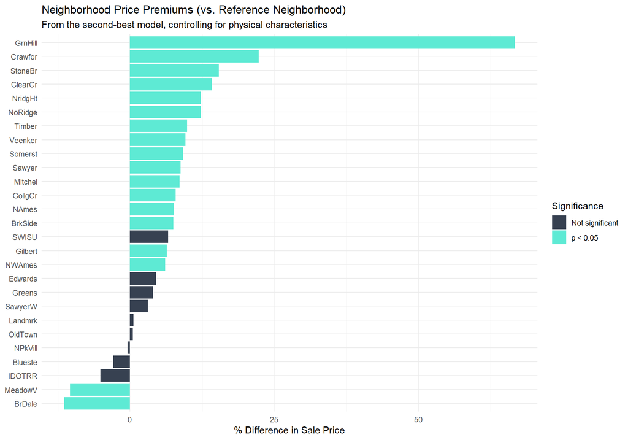

```r
# Visualize the neighborhood effects from the second model
nb_coefs <- tidy(second_model) |>
  filter(str_starts(term, "Neighborhood")) |>
  mutate(
    neighborhood = str_remove(term, "Neighborhood"),
    pct_effect = round((exp(estimate) - 1) * 100, 1),
    significant = p.value < 0.05
  ) |>
  arrange(desc(estimate))

ggplot(nb_coefs, aes(x = reorder(neighborhood, pct_effect),
                     y = pct_effect, fill = significant)) +
  geom_col() +
  scale_fill_manual(values = c("TRUE" = "#5eead4", "FALSE" = "#374151"),
                    labels = c("TRUE" = "p < 0.05", "FALSE" = "Not significant")) +
  coord_flip() +
  labs(
    title = "Neighborhood Price Premiums (vs. Reference Neighborhood)",
    subtitle = "From the second-best model, controlling for physical characteristics",
    x = NULL,
    y = "% Difference in Sale Price",
    fill = "Significance"
  ) +
  theme_minimal(base_size = 11)
```

#### Why Neighborhood Is Second-Best, Not Best

```r
# Side-by-side comparison
cat("=== 2nd Best Model Performance ===\n")
```

```
=== 2nd Best Model Performance ===
```

```r
cat(sprintf("R²:           %-12s %s\n",
    round(summary(best_model)$r.squared, 4),
    round(summary(second_model)$r.squared, 4)))
```

```
R²:           0.8721       0.8862
```

```r
cat(sprintf("Adj R²:       %-12s %s\n",
    round(summary(best_model)$adj.r.squared, 4),
    round(summary(second_model)$adj.r.squared, 4)))
```

```
Adj R²:       0.8716       0.8847
```

```r
cat(sprintf("AIC:          %-12s %s\n",
    round(AIC(best_model), 1),
    round(AIC(second_model), 1)))
```

```
AIC:          -2961.3      -3248.9
```

```r
cat(sprintf("Predictors:   %-12s %s\n",
    length(coef(best_model)) - 1,
    length(coef(second_model)) - 1))
```

```
Predictors:   11           38
```

```r
cat(sprintf("Resid SE:     %-12s %s\n",
    round(summary(best_model)$sigma, 5),
    round(summary(second_model)$sigma, 5)))
```

```
Resid SE:     0.14546      0.13784
```

That said, if the goal is specifically to predict prices **within Ames**, the second model with Neighborhood is the more accurate choice.

# Conclusion

**Prompting Overview:** For exercise D, the objective of the exercise was to determine the variables that are the greatest predictors of homesale price. I was able to achieve this entirely through using Claude’s Opus 4.6 to generate any graphs and visuals to help me understand the data in a more intuitive way, especially as someone outside the field of computer science. Opus 4.6 ability to generate R scripts was incredible, I was able to produce any of the steps within their own singular prompt, there was no need for additional prompting to produce each of the outcomes. However it is important to acknowledge that, it probably wouldn’t have been possible if I had attempted to put all 4 steps into a singular prompt. I believe it was vital to seperate out each of the tasks for the LLM to be effective. Another factor that I think helped the LLMs performance was an initial prompt that I requested the LLM read over the dataset first to determine important metrics that would determine salesprice and create a summary, before producing any kind of visualization. This initial context I believe added an effective guiding force as I went through all the steps as the LLM knew what to look for prior to creating the visualizations.

**Reflection:** The more I use LLMs the more I realize the importance of vocabulary and initial expertise that is vital to get the LLM to produce exactly what you want. I am not a data scientist, a computer scientist or in information technology, I am a product designer. If I didn’t have the initial prompts that you provided in the steps outlined in your .qmd file I wouldn’t have known what to be specifically asking for. If you hadn’t provided that initial context I would have struggled to come up with the language needed to get effective results. One difficulty I experienced throughout this process was that the AI used words that I didn’t know throughout its description of the different visualizations. I often had to look up words that I had no familiarity with just to understand what the LLM was referencing to. This made the process a bit more daunting, and I felt like the LLM did a lot of hand holding in this exercise for me. And when you form that kind of dependency your kinda in the dark as to how the LLM is even producing the outcomes, making it difficult for me to determine if the outcome is legitimate. This is the type of issue that worries me about AI, it can almost create a literal rabbit hole of outputs and the deeper your requests the less you understand how it came to that determination. I feel we may get to a point where we as humans could become completely in the dark as to what we are producing since we are have AI to produce it rather than ourselves. That I think is the real danger of all this, being able to create things that we are ourselves have little understanding of. On the brightside though, this exercise introduced me to a whole new avenue of knowledge that I previously had no experience with. And the ability to immediately encounter the cause and effects of this knowledge gave me a much more concrete understanding of it that it would have been if I had just read about those same concepts in a book. The ability to rapidly encounter and observes the effects of knowledge is a really cool side effect of using AI.